# NYPD Shooting Incident Data

Matthew Esser

2023-10-16

# LET’S GET STARTED!

## IMPORT DATA

Let’s start by downloading the data from the url provided:

```r
df <- read.csv('https://data.cityofnewyork.us/api/views/833y-fsy8/rows.csv?accessType=DOWNLOAD')
```

Now that we have our initial data, we’ll call the summary function to get an overview of data.

```
##   INCIDENT_KEY        OCCUR_DATE         OCCUR_TIME            BORO
##  Min.   :  9953245   Length:27312       Length:27312       Length:27312
##  1st Qu.: 63860880   Class :character   Class :character   Class :character
##  Median : 90372218   Mode  :character   Mode  :character   Mode  :character
##  Mean   :120860536
##  3rd Qu.:188810230
##  Max.   :261190187
##
##  LOC_OF_OCCUR_DESC     PRECINCT      JURISDICTION_CODE LOC_CLASSFCTN_DESC
##  Length:27312       Min.   :  1.00   Min.   :0.0000    Length:27312
##  Class :character   1st Qu.: 44.00   1st Qu.:0.0000    Class :character
##  Mode  :character   Median : 68.00   Median :0.0000    Mode  :character
##                     Mean   : 65.64   Mean   :0.3269
##                     3rd Qu.: 81.00   3rd Qu.:0.0000
##                     Max.   :123.00   Max.   :2.0000
##                                      NA's   :2
##  LOCATION_DESC      STATISTICAL_MURDER_FLAG PERP_AGE_GROUP
##  Length:27312       Length:27312            Length:27312
##  Class :character   Class :character        Class :character
##  Mode  :character   Mode  :character        Mode  :character
##
##
##
##
##    PERP_SEX          PERP_RACE         VIC_AGE_GROUP        VIC_SEX
##  Length:27312       Length:27312       Length:27312       Length:27312
##  Class :character   Class :character   Class :character   Class :character
##  Mode  :character   Mode  :character   Mode  :character   Mode  :character
##
##
##
##
##    VIC_RACE           X_COORD_CD        Y_COORD_CD        Latitude
##  Length:27312       Min.   : 914928   Min.   :125757   Min.   :40.51
##  Class :character   1st Qu.:1000029   1st Qu.:182834   1st Qu.:40.67
##  Mode  :character   Median :1007731   Median :194487   Median :40.70
##                     Mean   :1009449   Mean   :208127   Mean   :40.74
##                     3rd Qu.:1016838   3rd Qu.:239518   3rd Qu.:40.82
##                     Max.   :1066815   Max.   :271128   Max.   :40.91
##                                                        NA's   :10
##    Longitude        Lon_Lat
##  Min.   :-74.25   Length:27312
##  1st Qu.:-73.94   Class :character
##  Median :-73.92   Mode  :character
##  Mean   :-73.91
##  3rd Qu.:-73.88
##  Max.   :-73.70
##  NA's   :10
```

Let’s see an example of the data. *Using the head function*

```
##   INCIDENT_KEY OCCUR_DATE OCCUR_TIME     BORO LOC_OF_OCCUR_DESC PRECINCT
## 1    228798151 05/27/2021   21:30:00   QUEENS                        105
## 2    137471050 06/27/2014   17:40:00    BRONX                         40
## 3    147998800 11/21/2015   03:56:00   QUEENS                        108
## 4    146837977 10/09/2015   18:30:00    BRONX                         44
## 5     58921844 02/19/2009   22:58:00    BRONX                         47
## 6    219559682 10/21/2020   21:36:00 BROOKLYN                         81
##   JURISDICTION_CODE LOC_CLASSFCTN_DESC LOCATION_DESC STATISTICAL_MURDER_FLAG
## 1                 0                                                    false
## 2                 0                                                    false
## 3                 0                                                     true
## 4                 0                                                    false
## 5                 0                                                     true
## 6                 0                                                     true
##   PERP_AGE_GROUP PERP_SEX PERP_RACE VIC_AGE_GROUP VIC_SEX       VIC_RACE
```

[output cut: 20 more lines]

Now to keep in mind what data we are dealing with, let’s list the names of the columns.

**COLUMN NAMES:**

1. INCIDENT_KEY
2. OCCUR_DATE
3. OCCUR_TIME
4. BORO
5. LOC_OF_OCCUR_DESC
6. PRECINCT
7. JURISDICTION_CODE
8. LOC_CLASSFCTN_DESC
9. LOCATION_DESC
10. STATISTICAL_MURDER_FLAG
11. PERP_AGE_GROUP
12. PERP_SEX
13. PERP_RACE
14. VIC_AGE_GROUP
15. VIC_SEX
16. VIC_RACE
17. X_COORD_CD
18. Y_COORD_CD
19. Latitude
20. Longitude
21. Lon_Lat

## CLEAN DATA

In data science, I found it is good practice when modifying data to make an experimental copy. That way you have a base to return to if something goes wrong. Let’s make a copy of the data using the data.frame function.

```r
incidents <- data.frame(df)
```

When we get un-tidied data, it’s not unusual to come across several values being used in place of Null. This cell below us will go through the data and replace any common Null substitutes with NA.

```r
incidents[incidents == ""] <- NA
incidents[incidents == "U"] <- NA
incidents[incidents == "UNKNOWN"] <- NA
incidents[incidents == "(null)"] <- NA
incidents[incidents == "None"] <- NA
```

Now that we have found and replaced the common Null substitutes, let’s see how much null data is in the dataframe per column.

```
## [1] "INCIDENT_KEY 0"
```

```
## [1] "OCCUR_DATE 0"
```

```
## [1] "OCCUR_TIME 0"
```

```
## [1] "BORO 0"
```

```
## [1] "LOC_OF_OCCUR_DESC 25596"
```

```
## [1] "PRECINCT 0"
```

```
## [1] "JURISDICTION_CODE 2"
```

```
## [1] "LOC_CLASSFCTN_DESC 25596"
```

```
## [1] "LOCATION_DESC 15954"
```

```
## [1] "STATISTICAL_MURDER_FLAG 0"
```

```
## [1] "PERP_AGE_GROUP 13132"
```

```
## [1] "PERP_SEX 11449"
```

```
## [1] "PERP_RACE 11786"
```

```
## [1] "VIC_AGE_GROUP 61"
```

```
## [1] "VIC_SEX 11"
```

```
## [1] "VIC_RACE 66"
```

```
## [1] "X_COORD_CD 0"
```

```
## [1] "Y_COORD_CD 0"
```

```
## [1] "Latitude 10"
```

```
## [1] "Longitude 10"
```

```
## [1] "Lon_Lat 10"
```

As you can see, some columns like INCIDENT_KEY have no missing values, while others like LOC_OF_OCCUR_DESC have more than 90% of their data missing!

We have to make sure that the data is typed correctly, so let’s run this cell to fix OCCUR_DATE.

```r
incidents <- mutate(incidents,OCCUR_DATE = mdy(OCCUR_DATE))
```

One of the most important things to know in Data Science is when to drop features. Due to the high missing value count of LOC_OF_OCCUR_DESC and LOC_CLASS_FCTN_DESC, and the redundancy of Latitude,Longitude, and Lon_Lat we’ll be removing these columns.

```r
incidents <- incidents %>% subset(select=-c(LOC_OF_OCCUR_DESC,LOC_CLASSFCTN_DESC,Latitude,Longitude,Lon_Lat))
```

Now that we have gotten rid of the unnecessary columns, we can replace the NA values and incorrect data with values we are able to recognize and use.

```r
incidents$JURISDICTION_CODE<-replace(incidents$JURISDICTION_CODE, is.na(incidents$JURISDICTION_CODE), 0)
incidents$VIC_AGE_GROUP<-replace(incidents$VIC_AGE_GROUP, incidents$VIC_AGE_GROUP=='1022', 'UNKNOWN')
incidents$VIC_AGE_GROUP<-replace(incidents$VIC_AGE_GROUP, incidents$VIC_AGE_GROUP=='940', 'UNKNOWN')
incidents$VIC_AGE_GROUP<-replace(incidents$VIC_AGE_GROUP, incidents$VIC_AGE_GROUP=='224', 'UNKNOWN')
incidents$PERP_AGE_GROUP<-replace(incidents$PERP_AGE_GROUP, incidents$PERP_AGE_GROUP=='1020', 'UNKNOWN')
incidents$PERP_AGE_GROUP<-replace(incidents$PERP_AGE_GROUP, incidents$PERP_AGE_GROUP=='940', 'UNKNOWN')
incidents$PERP_AGE_GROUP<-replace(incidents$PERP_AGE_GROUP, incidents$PERP_AGE_GROUP=='224', 'UNKNOWN')
incidents<-replace(incidents, is.na(incidents), 'UNKNOWN')
incidents$VIC_SEX<-replace(incidents$VIC_SEX, incidents$VIC_SEX=='UNKNOWN', 'U')
incidents$PERP_SEX<-replace(incidents$PERP_SEX, incidents$PERP_SEX=='UNKNOWN', 'U')
```

Let’s run a quick value count on these columns to make sure we replaced the data properly.

```r
table(incidents$VIC_AGE_GROUP)
```

```
##
##     <18   18-24   25-44   45-64     65+ UNKNOWN
##    2839   10086   12281    1863     181      62
```

```r
table(incidents$PERP_AGE_GROUP)
```

```
##
##     <18   18-24   25-44   45-64     65+ UNKNOWN
##    1591    6222    5687     617      60   13135
```

```r
table(incidents$VIC_RACE)
```

```
##
## AMERICAN INDIAN/ALASKAN NATIVE       ASIAN / PACIFIC ISLANDER
##                             10                            404
##                          BLACK                 BLACK HISPANIC
##                          19439                           2646
##                        UNKNOWN                          WHITE
##                             66                            698
##                 WHITE HISPANIC
##                           4049
```

```r
table(incidents$PERP_RACE)
```

```
##
## AMERICAN INDIAN/ALASKAN NATIVE       ASIAN / PACIFIC ISLANDER
##                              2                            154
##                          BLACK                 BLACK HISPANIC
##                          11432                           1314
##                        UNKNOWN                          WHITE
##                          11786                            283
##                 WHITE HISPANIC
##                           2341
```

```r
table(incidents$VIC_SEX)
```

```
##
##     F     M     U
##  2615 24686    11
```

```r
table(incidents$PERP_SEX)
```

```
##
##     F     M     U
##   424 15439 11449
```

```r
summary(incidents)
```

```
##   INCIDENT_KEY         OCCUR_DATE          OCCUR_TIME            BORO
##  Min.   :  9953245   Min.   :2006-01-01   Length:27312       Length:27312
##  1st Qu.: 63860880   1st Qu.:2009-07-18   Class :character   Class :character
##  Median : 90372218   Median :2013-04-29   Mode  :character   Mode  :character
##  Mean   :120860536   Mean   :2014-01-06
##  3rd Qu.:188810230   3rd Qu.:2018-10-15
##  Max.   :261190187   Max.   :2022-12-31
##     PRECINCT      JURISDICTION_CODE LOCATION_DESC      STATISTICAL_MURDER_FLAG
##  Min.   :  1.00   Min.   :0.0000    Length:27312       Length:27312
##  1st Qu.: 44.00   1st Qu.:0.0000    Class :character   Class :character
##  Median : 68.00   Median :0.0000    Mode  :character   Mode  :character
##  Mean   : 65.64   Mean   :0.3269
##  3rd Qu.: 81.00   3rd Qu.:0.0000
##  Max.   :123.00   Max.   :2.0000
##  PERP_AGE_GROUP       PERP_SEX          PERP_RACE         VIC_AGE_GROUP
##  Length:27312       Length:27312       Length:27312       Length:27312
##  Class :character   Class :character   Class :character   Class :character
##  Mode  :character   Mode  :character   Mode  :character   Mode  :character
##
##
##
##    VIC_SEX            VIC_RACE           X_COORD_CD        Y_COORD_CD
##  Length:27312       Length:27312       Min.   : 914928   Min.   :125757
##  Class :character   Class :character   1st Qu.:1000029   1st Qu.:182834
##  Mode  :character   Mode  :character   Median :1007731   Median :194487
##                                        Mean   :1009449   Mean   :208127
##                                        3rd Qu.:1016838   3rd Qu.:239518
##                                        Max.   :1066815   Max.   :271128
```

## MODIFY DATA

Now that our base data is all ready, let’s work on creating our aggregation tables to find trends over time and demographic groups.

We can start by adding Month and Year columns.

```r
incidents$MONTH <- month(incidents$OCCUR_DATE)
incidents$YEAR <- year(incidents$OCCUR_DATE)
```

Let’s then aggregate those columns into a month dataframe and year dataframe.

```r
month_count = incidents %>% group_by(MONTH)  %>%
  summarise(total_incidents = n(),.groups = 'drop')
year_count = incidents %>% group_by(YEAR)  %>%
  summarise(total_incidents = n(),.groups = 'drop')
df_grp_date = incidents %>% group_by(OCCUR_DATE)  %>%
    summarise(total_incidents = n(),.groups = 'drop')
```

We’ll also aggregate the demographics data for the victims and perps into their own tables.

```r
vic_race_count = incidents %>% group_by(VIC_RACE)  %>%
  summarise(total_incidents = n(),.groups = 'drop')
perp_race_count = incidents %>% group_by(PERP_RACE)  %>%
  summarise(total_incidents = n(),.groups = 'drop')
vic_sex_count = incidents %>% group_by(VIC_SEX)  %>%
  summarise(total_incidents = n(),.groups = 'drop')
perp_sex_count = incidents %>% group_by(PERP_SEX)  %>%
  summarise(total_incidents = n(),.groups = 'drop')
vic_age_count = incidents %>% group_by(VIC_AGE_GROUP)  %>%
  summarise(total_incidents = n(),.groups = 'drop')
perp_age_count = incidents %>% group_by(PERP_AGE_GROUP)  %>%
  summarise(total_incidents = n(),.groups = 'drop')
```

```r
race_count <- full_join(vic_race_count,perp_race_count,by=c('VIC_RACE'='PERP_RACE'))
sex_count <- full_join(vic_sex_count,perp_sex_count,by=c("VIC_SEX"="PERP_SEX"))
age_count <- full_join(vic_age_count,perp_age_count,by=c("VIC_AGE_GROUP"="PERP_AGE_GROUP"))
```

## ANALYZE DATA

To get a big picture overview, here is a geographic scatter plot which clearly displays the incident map data. *To get a better understanding of this data, compare it against a map of New York.*

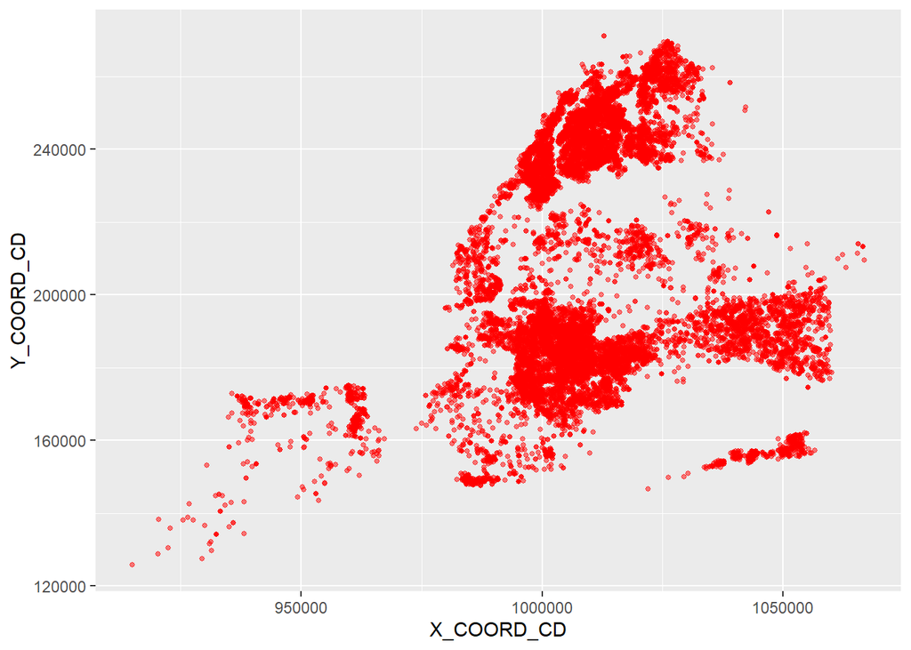

```r
ggplot() + geom_point(data=incidents, aes(x=X_COORD_CD, y=Y_COORD_CD), color="red", size=1, alpha=0.5)
```

Let’s now take a look at how incident rates change over time.

First let’s look at how the incident rates change throught a calendar year.

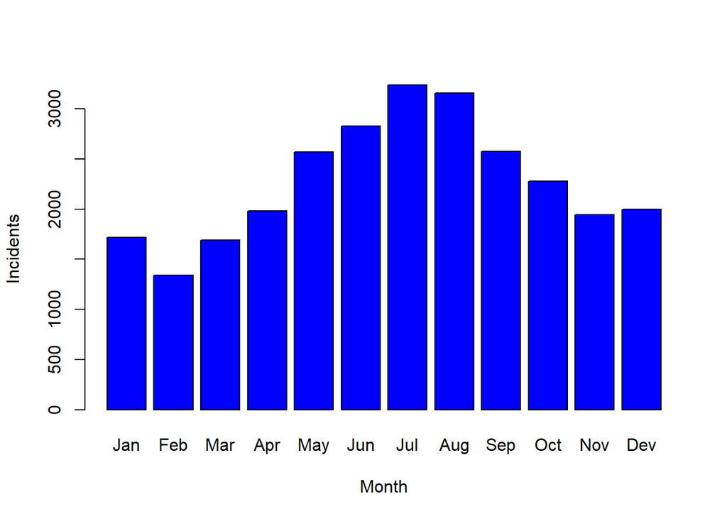

```r
barplot(height=month_count$total_incidents,
        col=c('blue'),
        xlab='Month',
        ylab='Incidents',
        names=c('Jan','Feb','Mar','Apr','May','Jun','Jul','Aug','Sep','Oct','Nov','Dev'))
```

As you can see, the data suggests that June thru August are the highest incident months. These are coincidentally some of the hottest months in New York leading to speculate a possible correlation between heat and violent crime.

Now let’s take a look at how the incident rate per year has changed over the past few years.

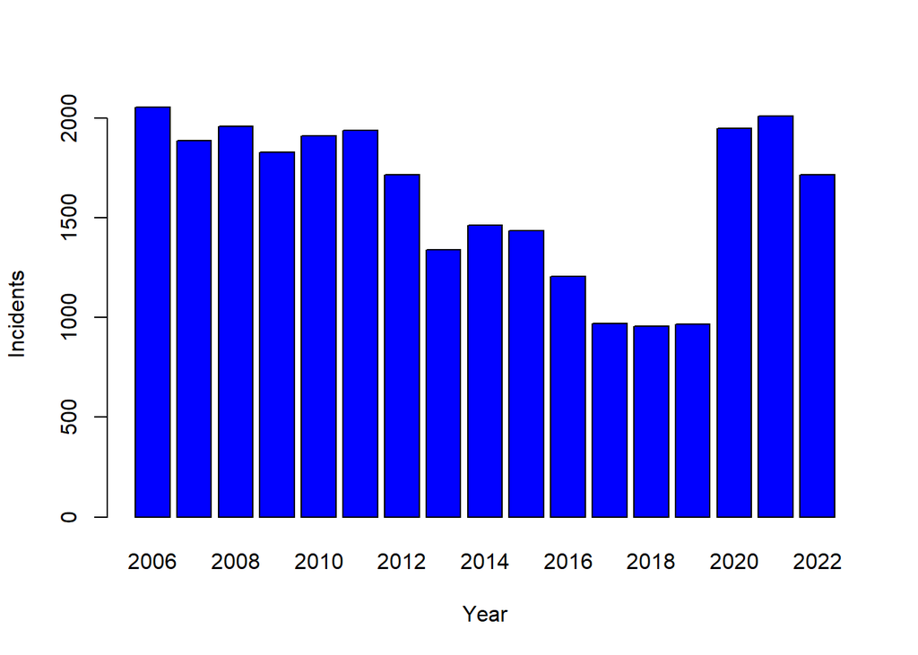

```r
barplot(height=year_count$total_incidents,
        col=c('blue'),
        xlab='Year',
        ylab='Incidents',
        names=year_count$YEAR)
```

We should also take a look at demographics of victims and perpetrators and see how they compare.

Let’s first compare perp and vic race demographics.

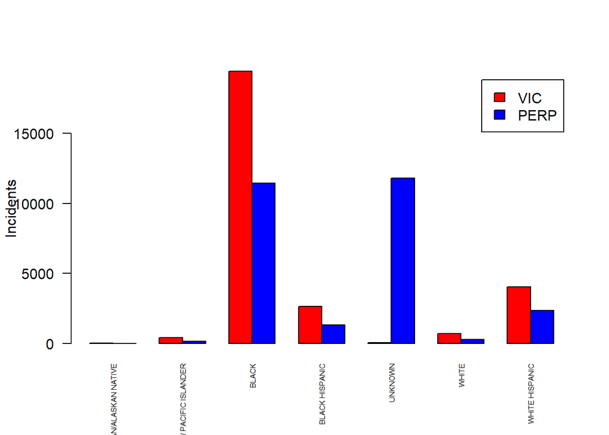

```r
cols <- c('red','blue')
barplot(
  t(race_count[c('total_incidents.x','total_incidents.y')]),
  beside=T,
  col=cols,
  legend.text=c('VIC','PERP'),
  ylab='Incidents',
  names.arg=race_count$VIC_RACE,
  cex.names = 0.5,
  las=2)
```

As you can see from data, black people seem to be the most likely to be victims of an incident. In many cases, it seems the race of a perpetrator is unknown.

Let’s first compare perp and vic gender demographics.

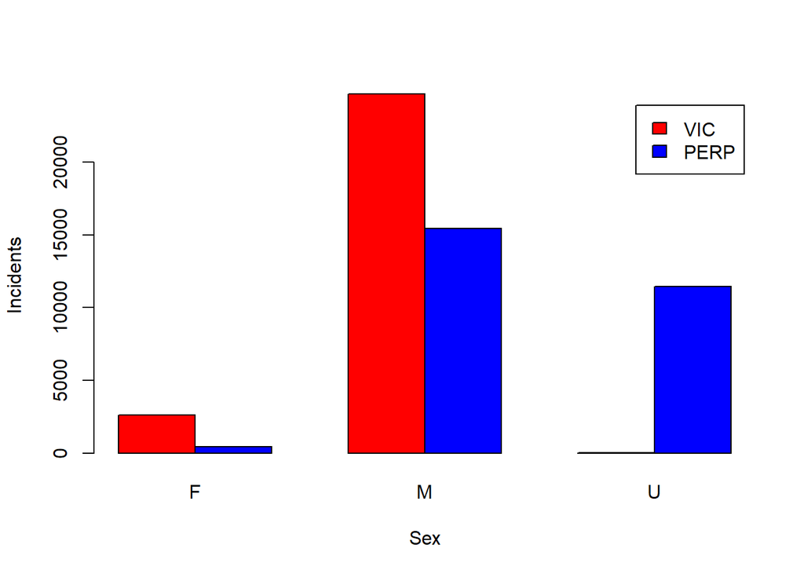

```r
cols <- c('red','blue')
barplot(
  t(sex_count[c('total_incidents.x','total_incidents.y')]),
  beside=T,
  col=cols,
  xlab='Sex',
  ylab='Incidents',
  legend.text=c('VIC','PERP'),
  names.arg=sex_count$VIC_SEX)
```

It appears from the data that men are more likely to be a victim or perpetrator of a shooting incident than women.

Let’s first compare perp and vic age demographics.

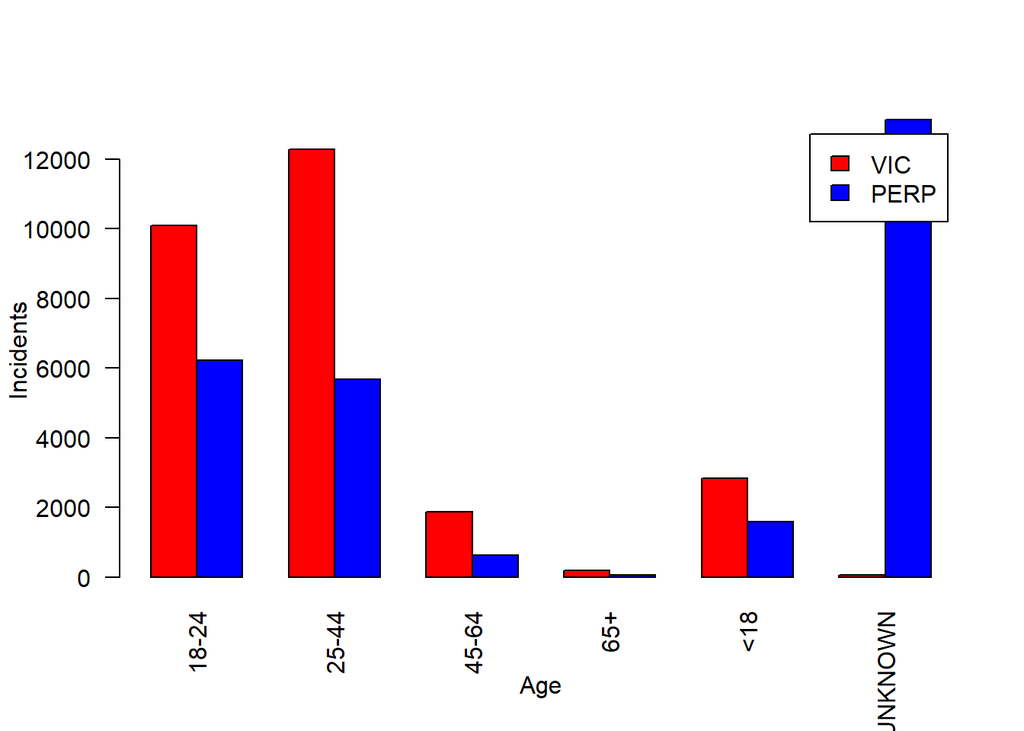

```r
cols <- c('red','blue')
barplot(
  t(age_count[c('total_incidents.x','total_incidents.y')]),
  beside=T,
  col=cols,
  legend.text=c('VIC','PERP'),
  xlab='Age',
  ylab='Incidents',
  names.arg=age_count$VIC_AGE_GROUP,
  las=2)
```

## MODEL DATA

Let’s use our date aggregated data to find a best fit line for incident rates over time.

Start by creating a linear regression model.

```r
mod <- lm(total_incidents~OCCUR_DATE,data=df_grp_date)
summary(mod)
```

```
##
## Call:
## lm(formula = total_incidents ~ OCCUR_DATE, data = df_grp_date)
##
## Residuals:
##    Min     1Q Median     3Q    Max
## -4.378 -2.500 -0.965  1.684 42.725
##
## Coefficients:
##               Estimate Std. Error t value Pr(>|t|)
## (Intercept)  8.132e+00  4.231e-01  19.220  < 2e-16 ***
## OCCUR_DATE  -2.091e-04  2.592e-05  -8.064 8.88e-16 ***
## ---
## Signif. codes:  0 '***' 0.001 '**' 0.01 '*' 0.05 '.' 0.1 ' ' 1
##
## Residual standard error: 3.559 on 5759 degrees of freedom
## Multiple R-squared:  0.01117,    Adjusted R-squared:  0.01099
## F-statistic: 65.03 on 1 and 5759 DF,  p-value: 8.884e-16
```

Create a database to store expected and actual values.

```r
df_pred <- df_grp_date %>% mutate(pred= predict(mod))
```

Plot expected values vs actual values and see how the trend operates.

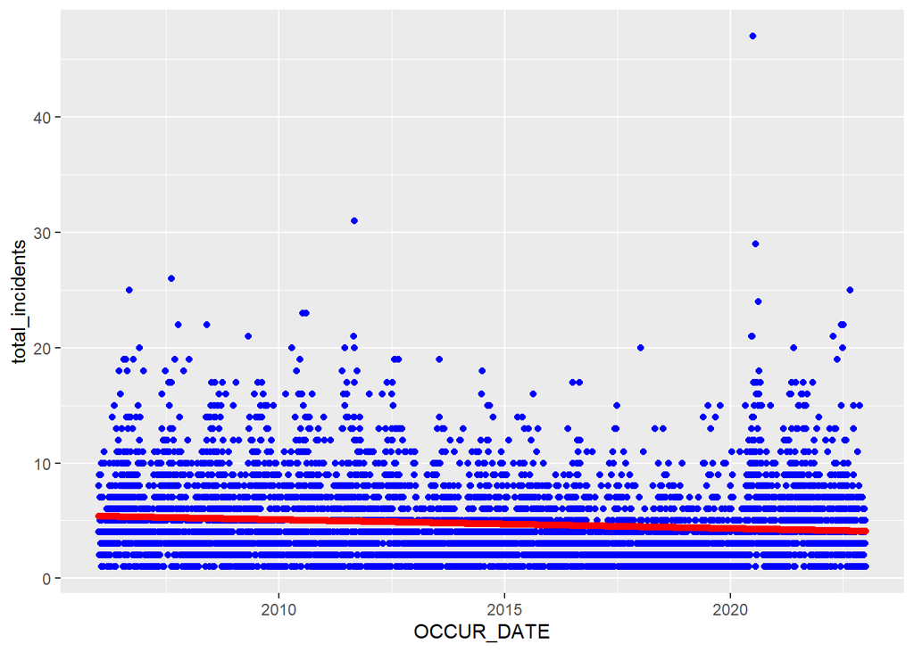

```r
df_pred %>% ggplot() + geom_point(aes(x=OCCUR_DATE,y=total_incidents),color="blue") + geom_point(aes(x=OCCUR_DATE,y=pred),color="red")
```

As the linear model suggests, despite a recent hike in 2020 incident rates in New York are on a downward trend.

## CONCLUSION

This data has revealed a great deal about shooting incidents in New York. While it certainly suggests that shooting that black people and men are much more likely to be victims or perpetrators of incidents, we need to be wary of bias. The most obvious opportunity for bias is in the perpetrator demographics. For perpetrators not caught or wrongfully arrested, this can be highly influenced by the implicit biases of eye-witness testimony. However we can also see that shooting incidents seem to be on a downward trend.